# rr_tsa_shinyapp

Mateusz Kijewski

2020-06-10

## General description

The project enables user to run Shiny app for Time series analysis. Also it implements S4 class tsExt which extends the xts class with more methods for plotting or testing the time series.

## User step by step guide

The first page of the application is the Home page – here a user can upload a .CSV file which will be used in further steps. The file needs to be the time series format (first column is data index and second one is time series) – we provide a sample dataset to test the application (demo.csv). There is also a “Create RMarkdown report” button on this page, which can be used to generate a file with the analysis with default parameters.

In the second tab (Overview) there are presented some information about the time series – at the top of the page there is a plot which presents the time series, and at the bottom – basic statistics like minimum and maximum value, mean, frequency of the data and range of selected days. The title of the plot, as well as frequency and range of the data, can be set at the sidebar on the left.

The next two pages – Seasonality and Stationarity – are the tabs that enable to decompose the time series. A user can choose a seasonal component, select test to perform (Kruskal-Wallis, QS, KPSS test, Augmented Dickey-Fuller) or differentiate the time series the desired number of times. The last tab is a tool for forecasting – here a user can choose a number of observations for the testing sample used in prediction, and the method of estimation: Naïve, ARIMA, or EMA.

## S4 Class description

The tsExt class has following methods:

[output not shown]

tsExt instance example:

[output not shown]

```r
test = read.table('../sample_data/demo.csv', header=TRUE, sep=',', colClasses=c("Date", rep("numeric", 6)))
data = as.xts(test[-1], order.by=test[[1]])
data = tsExt(data, name='Test', 'daily')
```

```r
plot_ts(data)
```

[interactive chart not shown]

```r
summary(data)
```

```
#>   name      min    max     mean  freq days
#> 1 Test 11.34143 324.74 95.73211 daily 4899
```

```r
test_season(data, 'all')
```

```
#>                  name                            null stat_val pval
#> 1 Kruskal-Wallis test Seasonal component don't exists 55.32709    1
#> 2             QS test Seasonal component don't exists  0.00000    1
```

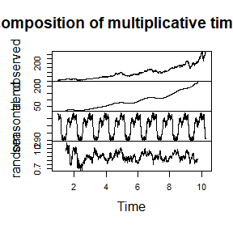

```r
plot_test(data, type = 'season', seas_type='multiplicative')
```

```r
test_station(data, 'all', 1)
```

```
#>            AAPL.Open
#> 2007-01-04 -0.320000
#> 2007-01-05  0.245714
#> 2007-01-08  0.027143
#> 2007-01-09  0.070000
#> 2007-01-10  1.185714
#> Warning in adf.test(data): p-value smaller than printed p-value
#>        name                null    stat_val       pval
#> 1  ADF test Non-stationary data -12.9217971 0.01000000
#> 2 KPSS test     Stationary data   0.4108343 0.07248519
```

```r
plot_test(data, type = 'station', n_dif=1)
```

```
#>            AAPL.Open
#> 2007-01-03  12.32714
#> 2007-01-04  12.00714
#> 2007-01-05  12.25286
#> 2007-01-08  12.28000
#> 2007-01-09  12.35000
```

[interactive chart not shown]